# Introduction to Crystallography

Dr. Ahmad Redaa

2024-09-11

# What is a Crystal?

- A **crystal** is a solid material with atoms, ions, or molecules arranged in a highly ordered, repeating pattern.
- The arrangement extends in all three spatial dimensions.
- Crystals exhibit distinct geometric shapes and properties, such as symmetry and regularity.
- Examples: Quartz, Diamond.

# Unit Cell

- The **unit cell** is the smallest repeating structural unit of a crystal lattice.
- It acts as the “building block” of the crystal.
- When repeated in three dimensions, the unit cell forms the entire crystal structure.

# Crystal Lattice

- A **crystal lattice** is the 3D framework of points that represent the repeating arrangement of atoms, ions, or molecules in a crystal.
- The pattern extends through the entire material, forming the structure of the crystal.
- Governs the physical and chemical properties of the crystal.

# Crystal Forms: Faces, Edges, and Corners

- **Faces**: Flat surfaces of a crystal.
- **Edges**: Lines where two crystal faces meet.
- **Corners**: Points where three or more edges meet.
- **Interfacial Angles**: The angle formed between two crystal faces.

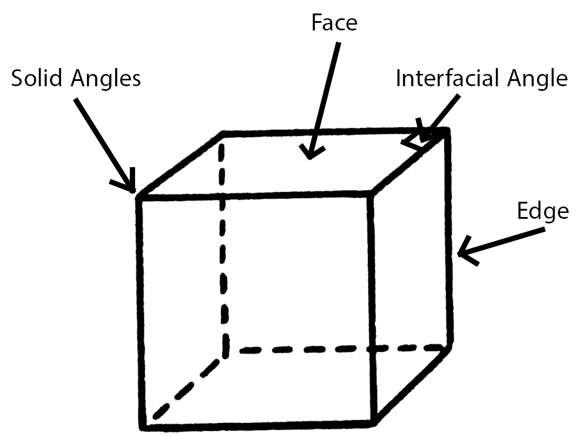

Crystal Elements of a cube

# Exercise:

Fill in the table below with the number of faces, corners, and edges for each crystal sketch.

Sketch of Crystal

No. of Faces

No. of Corners

No. of Edges

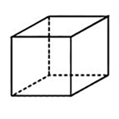

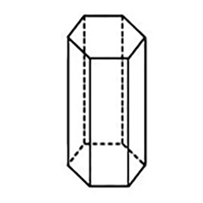

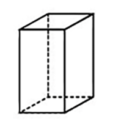

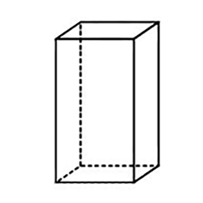

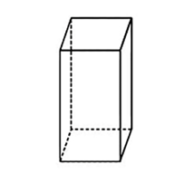

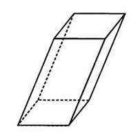

### Instructions:

1. For each sketch, identify and count the number of faces, corners, and edges.
2. Fill in the respective columns for each crystal.

# Crystal Axes

- **Crystal axes** are imaginary lines used to describe the symmetry and geometry of a crystal.
- These axes pass through the center of the crystal and extend in three dimensions.
- Typically, there are three axes: **a, b, and c**, which represent the length, width, and height of the crystal.
- The axes are often labeled with respect to their orientations.

## Angles Between Axes

- The angles between the crystal axes are crucial in defining the geometry of the crystal.
- **α (alpha)**: Angle between axes **b** and **c**.
- **β (beta)**: Angle between axes **a** and **c**.
- **γ (gamma)**: Angle between axes **a** and **b**.

# Exercise (2):

Fill in the table below with the correct axis lengths, angle geometries, and system names for each crystal sketch.

Sketch of Crystal

Sketch for Axes and Angles

Axis Lengths

Angles Geometry

System Name

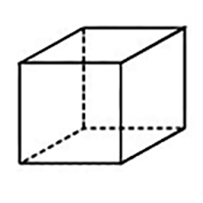

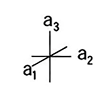

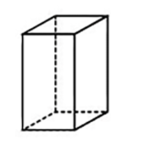

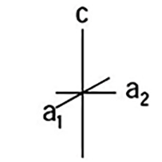

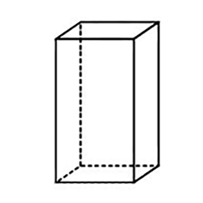

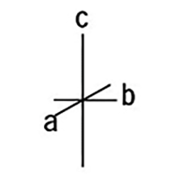

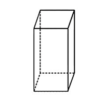

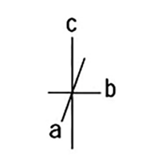

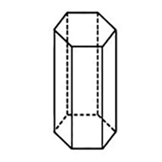

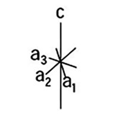

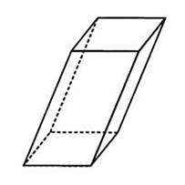

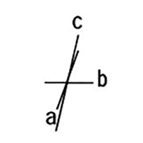

1. For each crystal sketch, observe the accompanying **axes and angles** sketch.
2. Based on the diagrams, fill in the **Axis Lengths** (e.g., a = b = c, a ≠ b ≠ c).
3. Describe the **Angles Geometry** (whether the angles are 90°, 120°, or none).
4. Identify the **Crystal System Name** based on the axes and angles provided.

# Identifying Crystal Systems

Crystal systems are categorized based on the lengths of the axes and the angles between them:

1. **Cubic**:
   - Axes: a = b = c
   - Angles: α = β = γ = 90°
2. **Tetragonal**:
   - Axes: a = b ≠ c
   - Angles: α = β = γ = 90°
3. **Orthorhombic**:
   - Axes: a ≠ b ≠ c
   - Angles: α = β = γ = 90°
4. **Hexagonal**:
   - Axes: a = b ≠ c
   - Angles: α = β = 90°, γ = 120°
5. **Monoclinic**:
   - Axes: a ≠ b ≠ c
   - Angles: α = γ = 90°, β ≠ 90°
6. **Triclinic**:
   - Axes: a ≠ b ≠ c
   - Angles: α ≠ β ≠ γ ≠ 90°